# TS Zillow Team Project (VAR CV model)

Oleksiy Anokhin

10/29/2020

### Intro

#### Packages

```r
# Install packages
library(tidyverse) # for general analysis
library(fpp)
# library(fpp2)
library(fpp3) # for predictions
# Important notice: the latest package here is fpp3, but it does not work well sometimes with 'ts' data.
# https://stackoverflow.com/questions/64348121/error-objects-of-type-ts-not-supported-by-autoplot-cannot-knit-rmarkdown-pack
# For example, I cannot use 'autoplot()' function for such data
# Hence, I will use fpp2 for this assignment
library(ggthemes) # for beautiful themes
# library(tinytex) # for pdf documents
# library(highcharter) # for beautiful charts
library(TSA) # for TS analysis
# library(readxl) # for xls files
library(kableExtra) # for beautiful tables
library(lubridate) # for time data
library(tsibble) # for tsiblle data format
# library(plotly) # for interactive charts
library(caret) # for modeling
library(prophet) # for TS analysis
library(lubridate)
library(zoo)
library(vars)
library(stats)
# library(forecast)
library(urca)
library(stats)

# Set a theme
theme_set(theme_minimal())

# Remove scientific notations for prices
options(scipen = 999)
```

#### Import data

This dataset was aggregated from two different datasets - Median Sale Price in Chicago (Zillow) and Average Mortgage Rate in Chicago area (Federal data).

```r
# Read data
chicago_data <- read_csv("VAR data.csv")

# Print
head(chicago_data)
```

```
## # A tibble: 6 x 3
##   Date      Median_price Average_rate
##   <chr>            <dbl>        <dbl>
## 1 2/29/2008       250000         5.92
## 2 3/31/2008       246000         5.97
## 3 4/30/2008       249000         5.92
## 4 5/31/2008       250000         6.04
## 5 6/30/2008       255000         6.32
## 6 7/31/2008       258500         6.43
```

#### EDA

```r
# Split data into train and test
Median_price_ts <- ts(chicago_data$Median_price, start = c(2008, 2), frequency = 12)

# Print
Median_price_ts
```

```
##         Jan    Feb    Mar    Apr    May    Jun    Jul    Aug    Sep    Oct
## 2008        250000 246000 249000 250000 255000 258500 255000 245000 235000
## 2009 215000 205000 215000 215000 218000 225000 220300 220000 211000 202000
## 2010 196000 187000 200000 201000 207500 220000 210000 216600 200000 199700
## 2011 180000 178000 171500 185000 184000 195000 200000 195000 175000 170000
## 2012 153000 150000 165000 175000 180500 198000 195000 186000 177000 162000
## 2013 153000 149000 164000 179000 192000 213750 213000 208500 197500 185400
## 2014 175000 167000 183000 192500 207500 225000 220000 222500 206000 192500
## 2015 182000 179000 199000 212000 220000 228500 224900 218000 210000 203000
## 2016 190000 185995 206250 223000 227750 232000 230000 223000 210000 210000
## 2017 205500 204000 222500 235000 235000 245000 240000 229700 222000 218000
## 2018 215000 217500 230000 239000 240000 249900 243000 233000 229000 222000
## 2019 216000 222000 232500 240000 246000 249500 249000 242000 235000 231000
## 2020 223000 225000 248000 260000 251000 254000 262000 270000
##         Nov    Dec
## 2008 225000 226000
## 2009 200000 200000
## 2010 190000 190750
## 2011 163000 160000
## 2012 166000 165000
## 2013 182000 180000
## 2014 190000 190000
## 2015 198000 199000
## 2016 207500 208000
## 2017 215000 219875
## 2018 223000 220000
## 2019 231250 230000
## 2020
```

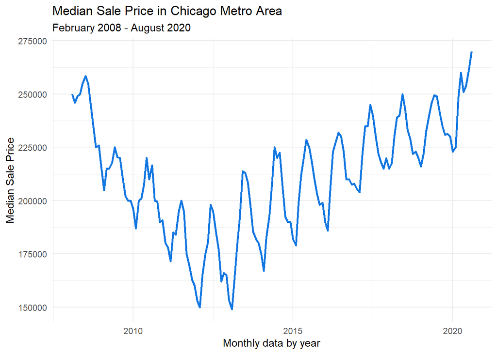

```r
# Plot
autoplot(Median_price_ts, color = "#1277e1", size = 1) +
         labs(title = "Median Sale Price in Chicago Metro Area", subtitle = "February 2008 - August 2020") +
         xlab("Monthly data by year") + ylab("Median Sale Price")
```

What can we see here?

- Decreasing and increasing trends
- Strong seasonality
- Data fluctuation changes in magnitude

```r
# Split data into train and test
Average_rate_ts <- ts(chicago_data$Average_rate, start = c(2008, 2), frequency = 12)

# Print
Average_rate_ts
```

```
##       Jan  Feb  Mar  Apr  May  Jun  Jul  Aug  Sep  Oct  Nov  Dec
## 2008      5.92 5.97 5.92 6.04 6.32 6.43 6.48 6.04 6.20 6.09 5.29
## 2009 5.05 5.13 5.00 4.81 4.86 5.42 5.22 5.19 5.06 4.95 4.88 4.93
## 2010 5.03 4.99 4.97 5.10 4.89 4.74 4.56 4.43 4.35 4.22 4.30 4.71
## 2011 4.76 4.95 4.84 4.84 4.64 4.51 4.54 4.27 4.11 4.07 3.99 3.96
## 2012 3.92 3.89 3.95 3.91 3.80 3.67 3.55 3.60 3.50 3.38 3.35 3.34
## 2013 3.41 3.53 3.56 3.45 3.54 4.07 4.37 4.46 4.49 4.19 4.26 4.46
## 2014 4.43 4.30 4.34 4.34 4.19 4.16 4.13 4.12 4.16 4.04 4.00 3.86
## 2015 3.67 3.71 3.77 3.67 3.84 3.98 4.05 3.91 3.89 3.80 3.94 3.96
## 2016 3.87 3.66 3.69 3.60 3.60 3.57 3.44 3.44 3.46 3.47 3.77 4.20
## 2017 4.15 4.17 4.20 4.04 4.01 3.90 3.97 3.88 3.80 3.90 3.92 3.95
## 2018 4.03 4.33 4.44 4.47 4.59 4.57 4.53 4.55 4.63 4.83 4.87 4.64
## 2019 4.46 4.37 4.26 4.14 4.07 3.80 3.77 3.62 3.60 3.69 3.70 3.72
## 2020 3.62 3.47 3.45 3.31 3.23 3.16 3.02 2.94
```

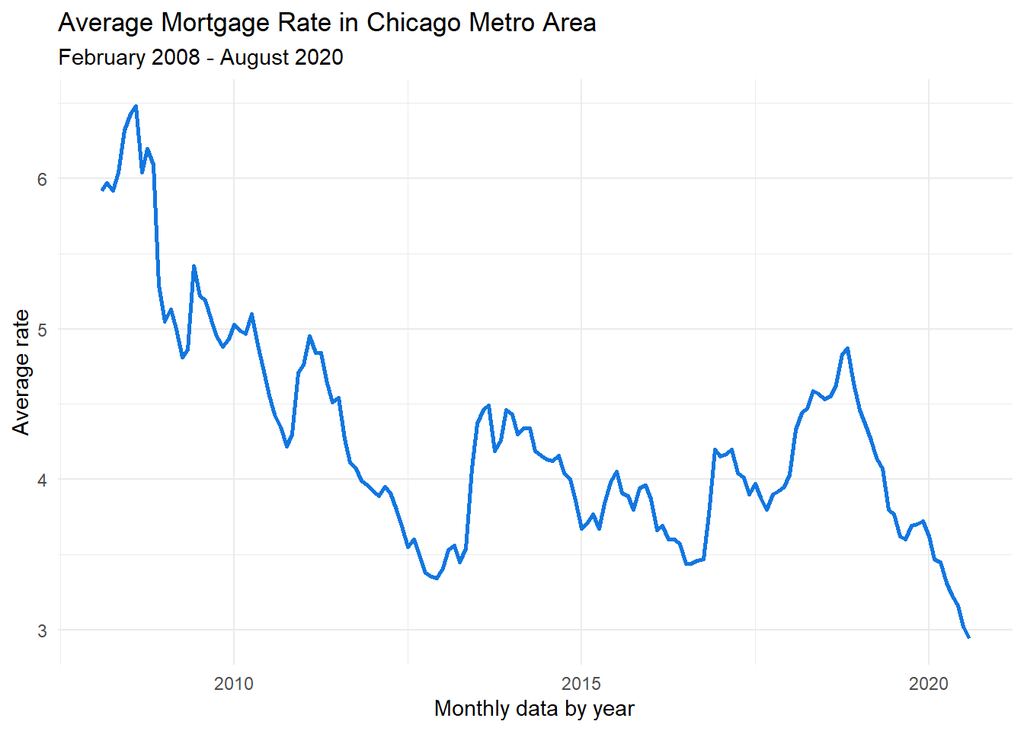

```r
# Plot
autoplot(Average_rate_ts, color = "#1277e1", size = 1) +
         labs(title = "Average Mortgage Rate in Chicago Metro Area", subtitle = "February 2008 - August 2020") +
         xlab("Monthly data by year") + ylab("Average rate")
```

#### Split into train and test data

```r
# Split train and test data for Median price
Median_price_ts_train <- window(Median_price_ts, end = c(2018, 12), frequency = 12)
Median_price_ts_test <- window(Median_price_ts, start = c(2019,1), end = c(2019,12), frequency = 12)

# Split train and test data for Average rate
Average_rate_ts_train <- ts(chicago_data$Average_rate, start = c(2008, 2), end = c(2014, 12), frequency = 12)
Average_rate_ts_test <- ts(chicago_data$Average_rate, start = c(2015, 1), end = c(2016, 12), frequency = 12)
```

```r
# Create a window
train_end <- c(2018, 12)
test_start <- c(2019, 1)
test_end <- c(2019, 12)
```

```r
# Define again train and test
Median_price_ts_train <- window(Median_price_ts, end = train_end)
Median_price_ts_test <- window(Median_price_ts, start = test_start, end = test_end)
```

```r
# Define again train and test
Average_rate_ts_train <- window(Average_rate_ts, end = train_end)
Average_rate_ts_test <- window(Average_rate_ts, start = test_start, end = test_end)
```

```r
# Check correlation
cor(Median_price_ts_train, Average_rate_ts_train)
```

```
## [1] 0.4876442
```

### VAR model

#### Stationarity

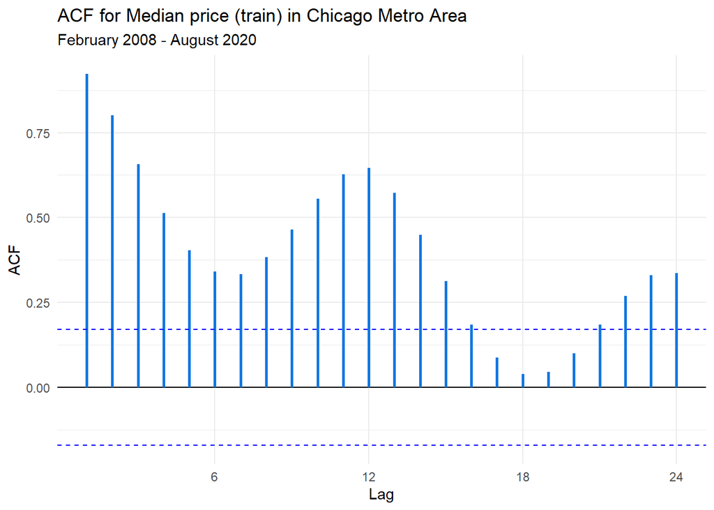

```r
# Check autocorrelation for Media price (train data)
ggAcf(Median_price_ts_train, color = "#1277e1", size = 1) +
         labs(title = "ACF for Median price (train) in Chicago Metro Area", subtitle = "February 2008 - August 2020")
```

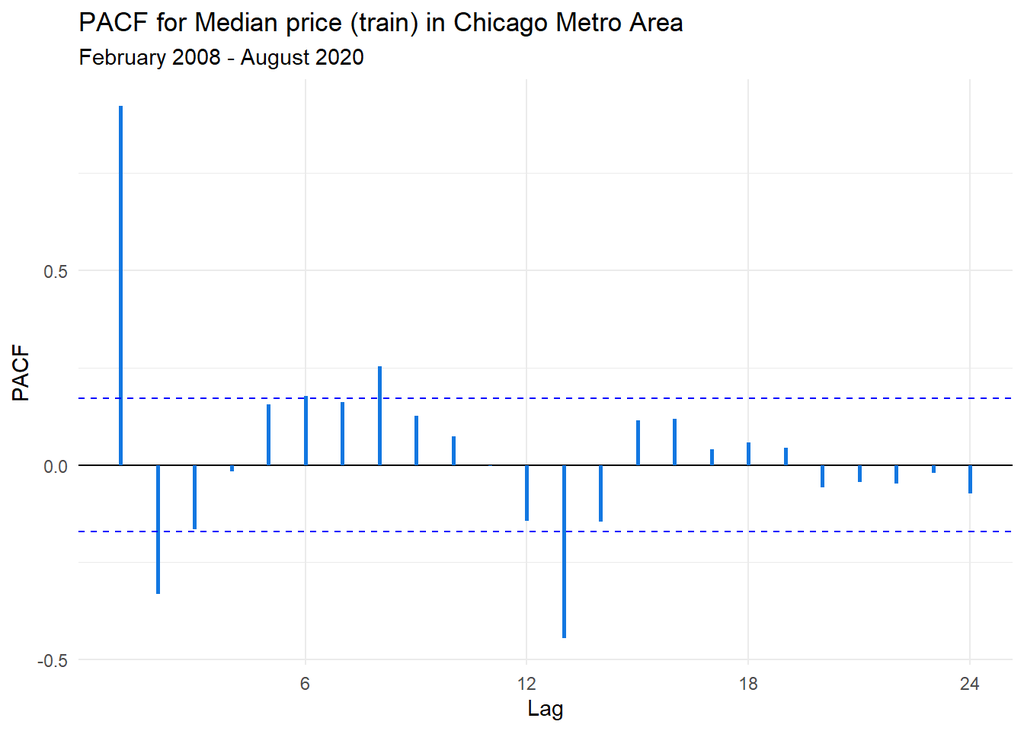

```r
# Check partial autocorrelation for Median price (train data)
ggPacf(Median_price_ts_train, color = "#1277e1", size = 1) +
         labs(title = "PACF for Median price (train) in Chicago Metro Area", subtitle = "February 2008 - August 2020")
```

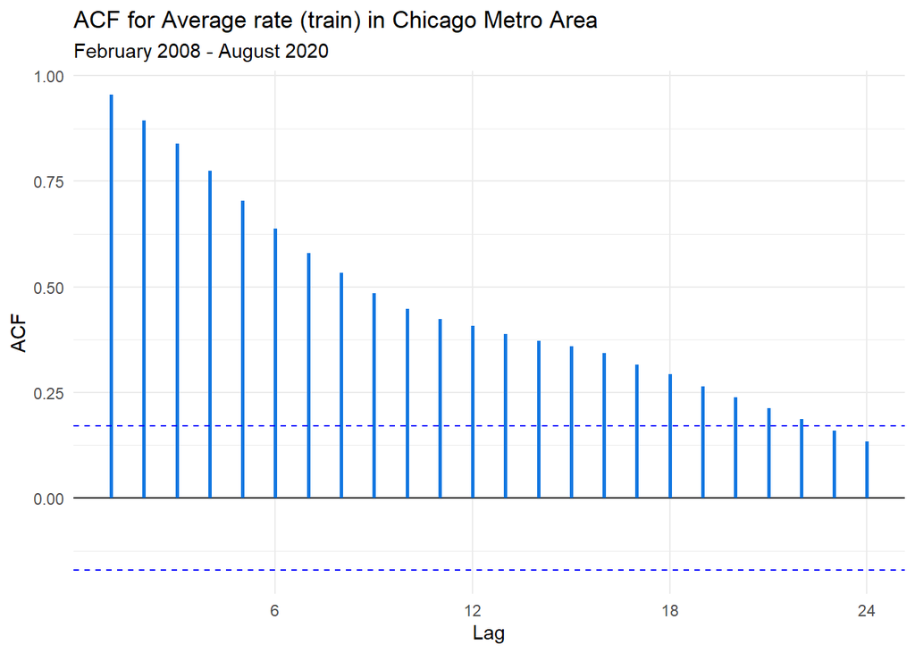

```r
# Check autocorrelation for Average rate (train data)
ggAcf(Average_rate_ts_train, color = "#1277e1", size = 1) +
         labs(title = "ACF for Average rate (train) in Chicago Metro Area", subtitle = "February 2008 - August 2020")
```

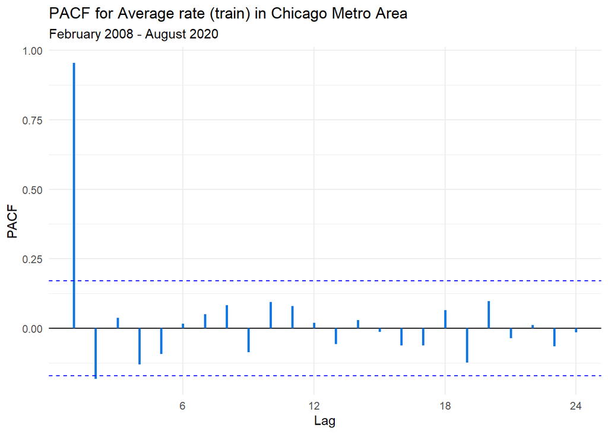

```r
# Check partial autocorrelation for Average rate (train data)
ggPacf(Average_rate_ts_train, color = "#1277e1", size = 1) +
         labs(title = "PACF for Average rate (train) in Chicago Metro Area", subtitle = "February 2008 - August 2020")
```

As we can see, we have a strong autocorrelation in both cases.

#### Tests

However, let;s check it formally with tests.

This is a slide from our Time Series class with Professor Abado as a reference.

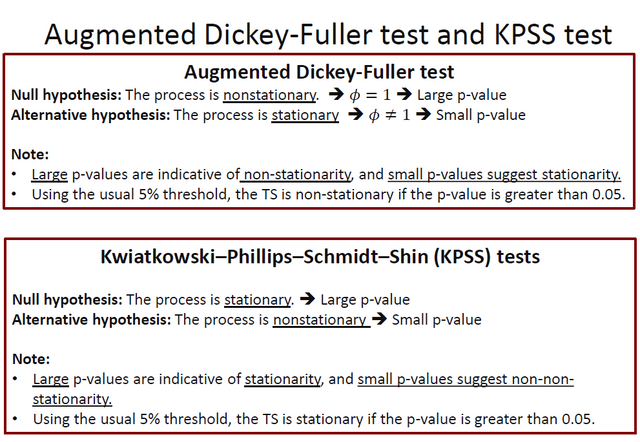

```r
# Run KPSS test for Median price train data
kpss.test(Median_price_ts_train)
```

```
##
##  KPSS Test for Level Stationarity
##
## data:  Median_price_ts_train
## KPSS Level = 0.55799, Truncation lag parameter = 4, p-value = 0.02861
```

```r
# Run KPSS test for Average rate train data
kpss.test(Average_rate_ts_train)
```

```
##
##  KPSS Test for Level Stationarity
##
## data:  Average_rate_ts_train
## KPSS Level = 1.3255, Truncation lag parameter = 4, p-value = 0.01
```

```r
# Run ADF test for Average rate train data
adf.test(Median_price_ts_train)
```

```
##
##  Augmented Dickey-Fuller Test
##
## data:  Median_price_ts_train
## Dickey-Fuller = -3.0201, Lag order = 5, p-value = 0.1523
## alternative hypothesis: stationary
```

```r
# Run ADF test for Average rate train data
adf.test(Average_rate_ts_train)
```

```
##
##  Augmented Dickey-Fuller Test
##
## data:  Average_rate_ts_train
## Dickey-Fuller = -2.5051, Lag order = 5, p-value = 0.3665
## alternative hypothesis: stationary
```

As we can see, both tests for both variables tell us that the process is not stationary.

#### VAR select

Now we will use `VARselect` and try to find a model.

```r
# VARselect
model1 <- VARselect(cbind(Median_price_ts_train, Average_rate_ts_train))

# Print
model1
```

```
## $selection
## AIC(n)  HQ(n)  SC(n) FPE(n)
##     10      9      2     10
##
## $criteria
##                    1             2             3             4             5
## AIC(n)      14.54858      14.37173      14.39791      14.42953      14.33075
## HQ(n)       14.60488      14.46558      14.52929      14.59845      14.53720
## SC(n)       14.68721      14.60279      14.72139      14.84544      14.83908
## FPE(n) 2081496.41384 1744238.45659 1790790.94975 1848868.00378 1675729.98436
##                    6             7             8             9            10
## AIC(n)      14.30007      14.25522      14.15522      14.06689      14.04513
## HQ(n)       14.54405      14.53674      14.47428      14.42348      14.43926
## SC(n)       14.90082      14.94839      14.94082      14.94490      15.01557
## FPE(n) 1626160.86407 1556234.33498 1409809.46425 1292549.23533 1267080.35395
```

`VARselect` offers us to try model with p = 10

#### Model

```r
# Var 10
varmodel10 <- VAR(cbind(Median_price_ts_train, Average_rate_ts_train), p = 10, type = "both", season = 12)

# Pormonteau test
serial.test(varmodel10, lags.pt = 20, type = "PT.asymptotic")
```

```
##
##  Portmanteau Test (asymptotic)
##
## data:  Residuals of VAR object varmodel10
## Chi-squared = 54.084, df = 40, p-value = 0.06771
```

```r
# p-value = 0.06771

# Print summary
summary(varmodel10)
```

```
##
## VAR Estimation Results:
## =========================
## Endogenous variables: Median_price_ts_train, Average_rate_ts_train
## Deterministic variables: both
## Sample size: 121
## Log Likelihood: -1091.574
## Roots of the characteristic polynomial:
## 0.966 0.948 0.948 0.8515 0.8515 0.8457 0.8268 0.8268 0.8135 0.8135 0.8067 0.8067 0.7933 0.7933 0.7797 0.7797 0.7551 0.7038 0.7038 0.2169
## Call:
## VAR(y = cbind(Median_price_ts_train, Average_rate_ts_train),
##     p = 10, type = "both", season = 12L)
##
##
## Estimation results for equation Median_price_ts_train:
## ======================================================
## Median_price_ts_train = Median_price_ts_train.l1 + Average_rate_ts_train.l1 + Median_price_ts_train.l2 + Average_rate_ts_train.l2 + Median_price_ts_train.l3 + Average_rate_ts_train.l3 + Median_price_ts_train.l4 + Average_rate_ts_train.l4 + Median_price_ts_train.l5 + Average_rate_ts_train.l5 + Med…
##
##                              Estimate  Std. Error t value       Pr(>|t|)
## Median_price_ts_train.l1      0.76899     0.10753   7.152 0.000000000241 ***
## Average_rate_ts_train.l1  -1627.77082  3228.58853  -0.504       0.615399
## Median_price_ts_train.l2      0.26614     0.13501   1.971       0.051840 .
## Average_rate_ts_train.l2   2324.54322  4912.84986   0.473       0.637274
## Median_price_ts_train.l3     -0.15877     0.13607  -1.167       0.246459
## Average_rate_ts_train.l3  -6274.59586  4826.17637  -1.300       0.196956
## Median_price_ts_train.l4     -0.16787     0.13720  -1.223       0.224408
## Average_rate_ts_train.l4   8465.77327  4742.66072   1.785       0.077703 .
## Median_price_ts_train.l5      0.02509     0.14034   0.179       0.858518
## Average_rate_ts_train.l5  -2619.17218  4743.78923  -0.552       0.582261
## Median_price_ts_train.l6      0.19706     0.13802   1.428       0.156902
## Average_rate_ts_train.l6  -1189.22423  4688.76988  -0.254       0.800371
## Median_price_ts_train.l7     -0.19438     0.13854  -1.403       0.164121
## Average_rate_ts_train.l7   2413.58802  4653.04928   0.519       0.605264
## Median_price_ts_train.l8      0.03150     0.13855   0.227       0.820689
## Average_rate_ts_train.l8  -7100.53288  4726.05556  -1.502       0.136568
## Median_price_ts_train.l9      0.15245     0.13284   1.148       0.254242
## Average_rate_ts_train.l9   1969.59986  4655.67580   0.423       0.673288
## Median_price_ts_train.l10     0.06886     0.10527   0.654       0.514748
## Average_rate_ts_train.l10   340.56877  3098.95564   0.110       0.912741
## const                     14458.03882  5777.60654   2.502       0.014182 *
```

[output cut: 97 more lines]

```
## Residual standard error: 0.1498 on 88 degrees of freedom
## Multiple R-Squared: 0.9381,  Adjusted R-squared: 0.9156
## F-statistic: 41.69 on 32 and 88 DF,  p-value: < 0.00000000000000022
##
##
##
## Covariance matrix of residuals:
##                       Median_price_ts_train Average_rate_ts_train
## Median_price_ts_train           20118003.37              84.80853
## Average_rate_ts_train                 84.81               0.02243
##
## Correlation matrix of residuals:
##                       Median_price_ts_train Average_rate_ts_train
## Median_price_ts_train                1.0000                0.1263
## Average_rate_ts_train                0.1263                1.0000
```

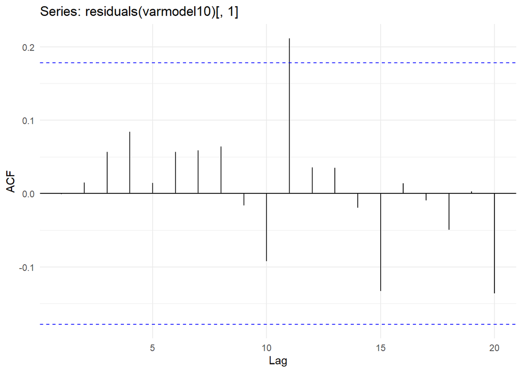

```r
# Check residuals for the model
ggAcf(residuals(varmodel10)[, 1])
```

#### Forecast

```r
# Create a forecast
varmodel10_forecast <- ts(predict(varmodel10, n.ahead = 12, ci = .95)$fcst$Median_price_ts_train[, 1], start = test_start, frequency = 12)
```

#### Evaluate model

Now we can check our numbers in different metrics.

```r
# Analyze accuracy
accuracy(varmodel10_forecast, Median_price_ts_test)
```

```
##               ME     RMSE      MAE      MPE     MAPE        ACF1 Theil's U
## Test set 4928.41 5802.577 5007.332 2.123653 2.155286 -0.01356779  1.063409
```

```r
accuracy(varmodel10_forecast, Average_rate_ts_test)
```

```
##                 ME     RMSE      MAE      MPE    MAPE      ACF1 Theil's U
## Test set -230421.8 230721.1 230421.8 -5899501 5899501 0.7030913   2087637
```

We can see that our key metrics - such as MAE and RMSE are pretty high, hopefully we can achieve better results in our next models.

#### Cross-Validation

```r
# Define parameters
k <- 72 # Minimum observations (6 years)
p <- 12 # Period
st <- 2014 + 11/12
```

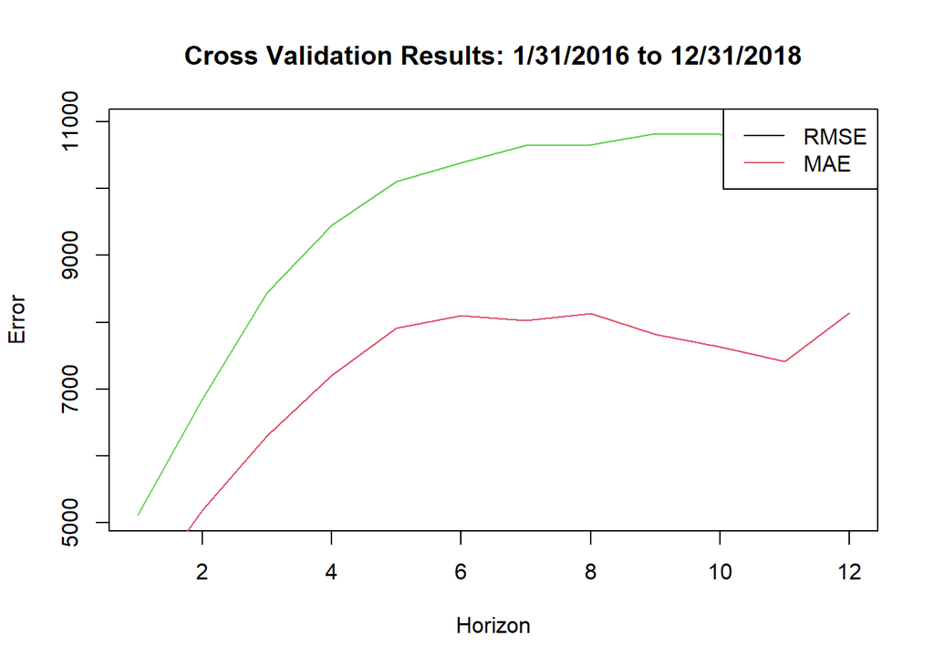

```r
error <- matrix(NA, 36, 12)
dates <- c()
for(i in (1:36))

# Create a function
{
  train <- window(Median_price_ts, start = st + (i - k + 1)/p, end = st + i/p)
  test <- window(Median_price_ts, start = st + (i + 1)/p, end = st + (i + 12)/p)
  rate_train <- window(Average_rate_ts, start = st + (i - k + 1)/p, end = st + i/p)
  rate_test <- window(Average_rate_ts, start = st + (i + 1)/p, end = st+(i + 12)/p)
  dates[i] <- st + (i + 12)/p
  var_model <-  VAR(cbind(train, rate_train), p = 10, type = "both", season = 12)

  f <- ts(predict(var_model, n.ahead = 12, ci = .95)$fcst$train[, 1], start = st + (i + 1)/p, frequency = 12)
  error[i, 1:length(test)] <- f - test
}

# Define and plot metrics
MAE <- colMeans(abs(error), na.rm = TRUE)
RMSE <- sqrt(colMeans(error**2, na.rm = TRUE))
plot(1:12, RMSE, type = "l", col = 3, xlab = "Horizon", ylab = "Error", main = 'Cross Validation Results: 1/31/2016 to 12/31/2018')
lines(1:12, MAE, type = "l", col = 2)
legend("topright", legend = c("RMSE", "MAE"), col = 1:4, lty = 1)
```

```r
# Print metrics
print(MAE)
```

```
##  [1] 3833.893 5192.403 6305.668 7207.826 7912.936 8102.737 8023.779 8130.189
##  [9] 7814.665 7629.533 7410.735 8140.014
```

```r
print(RMSE)
```

```
##  [1]  5114.885  6848.081  8442.385  9451.229 10102.229 10388.969 10644.397
##  [8] 10661.165 10818.159 10813.311 10633.666 10953.226
```

```r
print(sum(MAE)/12)
```

```
## [1] 7142.031
```

```r
print(sum(RMSE)/12)
```

```
## [1] 9572.642
```

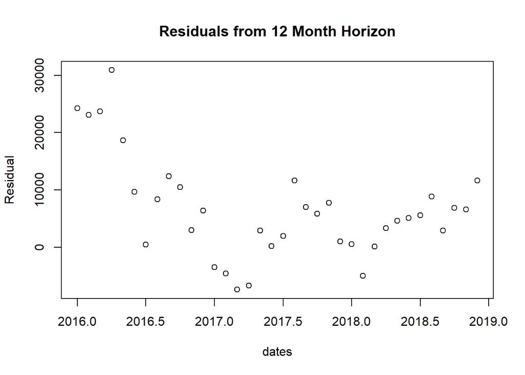

```r
# Plot residuals
plot(dates, error[, 12], ylab = 'Residual', main = 'Residuals from 12 Month Horizon')
```

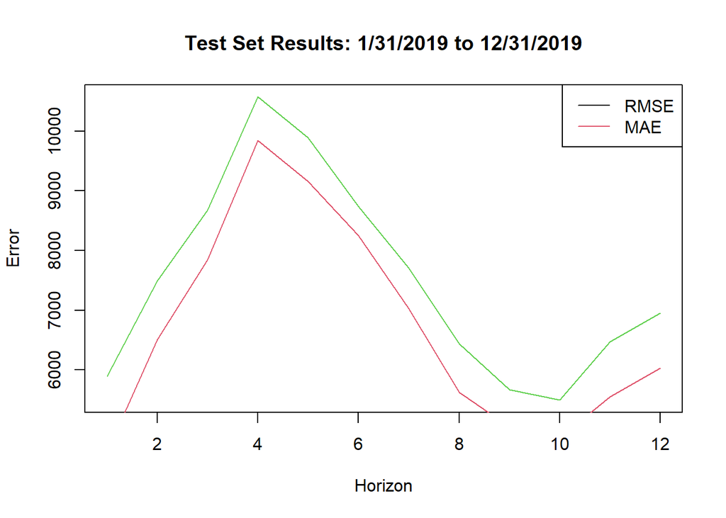

```r
error <- matrix(NA, 12, 12)
dates <- c()
for(i in (37:48))

{
  train <- window(Median_price_ts, start = st + (i - k + 1)/p, end = st + i/p)
  test <- window(Median_price_ts, start = st + (i + 1)/p, end = st + (i + 12)/p)
  rate_train <- window(Average_rate_ts, start = st + (i - k + 1)/p, end = st + i/p)
  rate_test <- window(Average_rate_ts, start = st + (i + 1)/p, end = st + (i + 12)/p)
  dates[i - 36] <- st + (i + 12)/p
  var_model <-  VAR(cbind(train, rate_train), p = 10, type = "both", season = 12)

  f <- ts(predict(var_model, n.ahead = 12, ci = .95)$fcst$train[, 1], start = st + (i + 1)/p, frequency = 12)
  error[i - 36, 1:length(test)] <- f - test
}

# Define metrics and plot them
MAE <- colMeans(abs(error), na.rm = TRUE)
RMSE <- sqrt(colMeans(error**2, na.rm = TRUE))
plot(1:12, RMSE, type = "l",col = 3, xlab = "Horizon", ylab = "Error", main = 'Test Set Results: 1/31/2019 to 12/31/2019')
lines(1:12, MAE, type = "l", col = 2)
legend("topright", legend = c("RMSE", "MAE"), col = 1:4, lty = 1)
```

```r
# Print metrics
print(MAE)
```

```
##  [1] 4631.413 6505.740 7845.780 9847.905 9157.982 8256.397 7035.908 5622.855
##  [9] 5046.721 4868.025 5551.898 6030.481
```

```r
print(RMSE)
```

```
##  [1]  5895.776  7493.981  8678.372 10573.746  9886.031  8743.235  7712.670
##  [8]  6435.117  5666.352  5495.104  6470.566  6948.062
```

```r
print(sum(MAE)/12)
```

```
## [1] 6700.092
```

```r
print(sum(RMSE)/12)
```

```
## [1] 7499.918
```

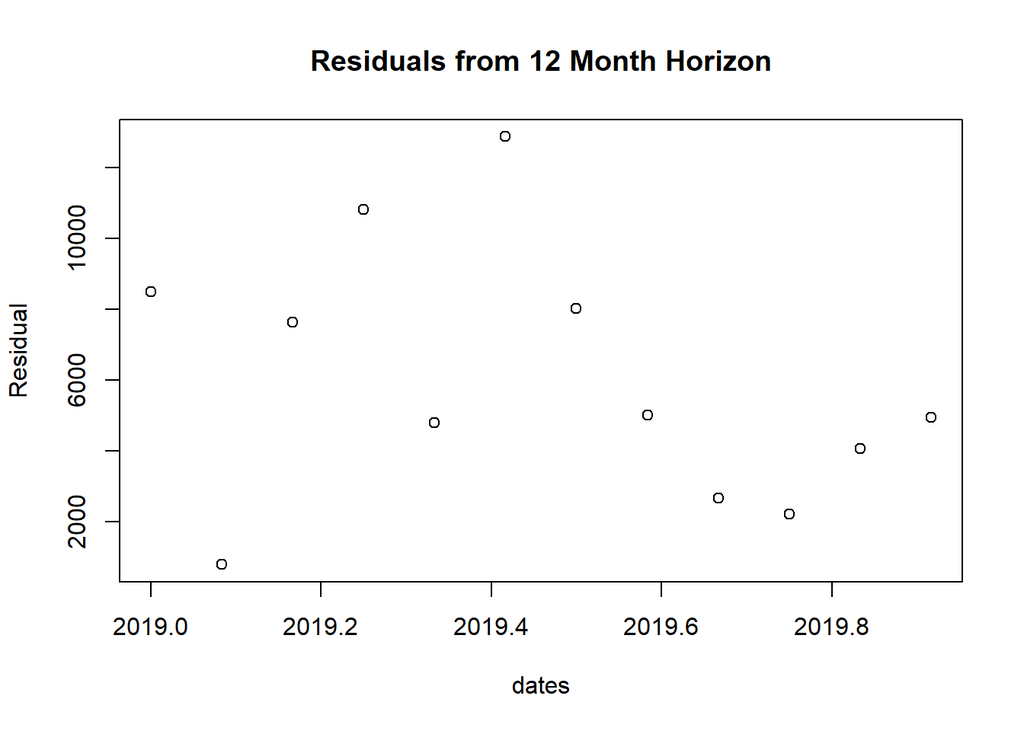

```r
# Plot residuals
plot(dates, error[, 12], ylab = 'Residual', main = 'Residuals from 12 Month Horizon')
```

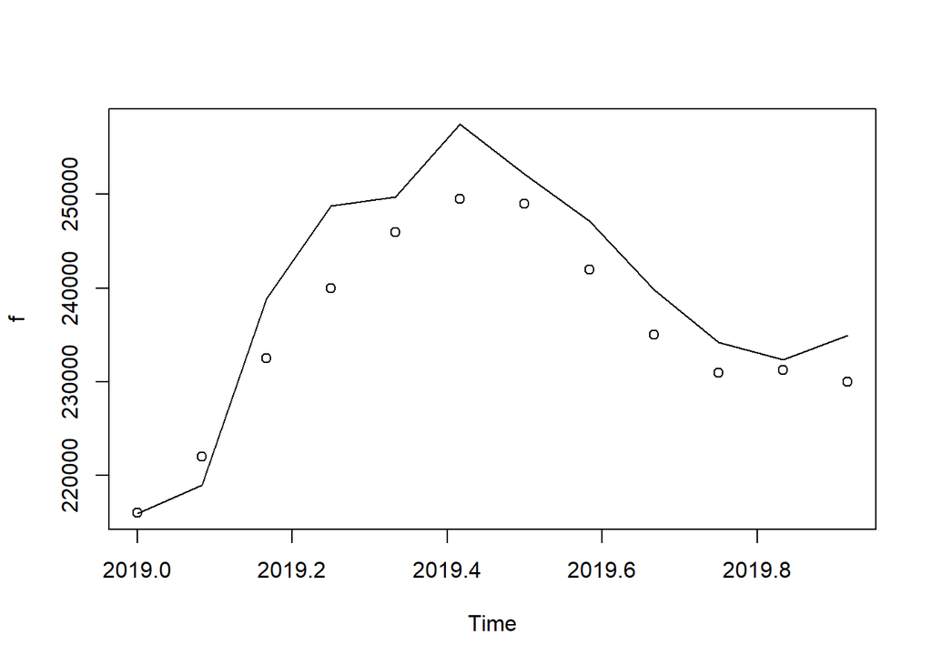

```r
plot(f)
points(test)
```

We can see that our prediction is not that accurate and we can do better here.

### VAR with Diff1

**Important:** Here and in all other steps I replicate the first result, so there is a lot of repetition here, which is still important.

#### 1st order differencing

First, we need to difference data (1st order).

```r
# Create new variables
Median_price_ts_diff1 <- diff(Median_price_ts, differences = 1)
Average_rate_ts_diff1 <- diff(Average_rate_ts, differences = 1)

# Check class
class(Median_price_ts_diff1)
```

```
## [1] "ts"
```

```r
class(Average_rate_ts_diff1)
```

```
## [1] "ts"
```

```r
# Print
Median_price_ts_diff1
```

```
##         Jan    Feb    Mar    Apr    May    Jun    Jul    Aug    Sep    Oct
## 2008                -4000   3000   1000   5000   3500  -3500 -10000 -10000
## 2009 -11000 -10000  10000      0   3000   7000  -4700   -300  -9000  -9000
## 2010  -4000  -9000  13000   1000   6500  12500 -10000   6600 -16600   -300
## 2011 -10750  -2000  -6500  13500  -1000  11000   5000  -5000 -20000  -5000
## 2012  -7000  -3000  15000  10000   5500  17500  -3000  -9000  -9000 -15000
## 2013 -12000  -4000  15000  15000  13000  21750   -750  -4500 -11000 -12100
## 2014  -5000  -8000  16000   9500  15000  17500  -5000   2500 -16500 -13500
## 2015  -8000  -3000  20000  13000   8000   8500  -3600  -6900  -8000  -7000
## 2016  -9000  -4005  20255  16750   4750   4250  -2000  -7000 -13000      0
## 2017  -2500  -1500  18500  12500      0  10000  -5000 -10300  -7700  -4000
## 2018  -4875   2500  12500   9000   1000   9900  -6900 -10000  -4000  -7000
## 2019  -4000   6000  10500   7500   6000   3500   -500  -7000  -7000  -4000
## 2020  -7000   2000  23000  12000  -9000   3000   8000   8000
##         Nov    Dec
## 2008 -10000   1000
## 2009  -2000      0
## 2010  -9700    750
## 2011  -7000  -3000
## 2012   4000  -1000
## 2013  -3400  -2000
## 2014  -2500      0
## 2015  -5000   1000
## 2016  -2500    500
## 2017  -3000   4875
## 2018   1000  -3000
## 2019    250  -1250
## 2020
```

```r
Average_rate_ts_diff1
```

```
##        Jan   Feb   Mar   Apr   May   Jun   Jul   Aug   Sep   Oct   Nov   Dec
## 2008              0.05 -0.05  0.12  0.28  0.11  0.05 -0.44  0.16 -0.11 -0.80
## 2009 -0.24  0.08 -0.13 -0.19  0.05  0.56 -0.20 -0.03 -0.13 -0.11 -0.07  0.05
## 2010  0.10 -0.04 -0.02  0.13 -0.21 -0.15 -0.18 -0.13 -0.08 -0.13  0.08  0.41
## 2011  0.05  0.19 -0.11  0.00 -0.20 -0.13  0.03 -0.27 -0.16 -0.04 -0.08 -0.03
## 2012 -0.04 -0.03  0.06 -0.04 -0.11 -0.13 -0.12  0.05 -0.10 -0.12 -0.03 -0.01
## 2013  0.07  0.12  0.03 -0.11  0.09  0.53  0.30  0.09  0.03 -0.30  0.07  0.20
## 2014 -0.03 -0.13  0.04  0.00 -0.15 -0.03 -0.03 -0.01  0.04 -0.12 -0.04 -0.14
## 2015 -0.19  0.04  0.06 -0.10  0.17  0.14  0.07 -0.14 -0.02 -0.09  0.14  0.02
## 2016 -0.09 -0.21  0.03 -0.09  0.00 -0.03 -0.13  0.00  0.02  0.01  0.30  0.43
## 2017 -0.05  0.02  0.03 -0.16 -0.03 -0.11  0.07 -0.09 -0.08  0.10  0.02  0.03
## 2018  0.08  0.30  0.11  0.03  0.12 -0.02 -0.04  0.02  0.08  0.20  0.04 -0.23
## 2019 -0.18 -0.09 -0.11 -0.12 -0.07 -0.27 -0.03 -0.15 -0.02  0.09  0.01  0.02
## 2020 -0.10 -0.15 -0.02 -0.14 -0.08 -0.07 -0.14 -0.08
```

```r
# Define again train and test for Median price
Median_price_ts_train_diff1 <- window(Median_price_ts_diff1, end = train_end)
Median_price_ts_test_diff1 <- window(Median_price_ts_diff1, start = test_start, end = test_end)
```

```r
# Define again train and test for Average rate
Average_rate_ts_train_diff1 <- window(Average_rate_ts_diff1, end = train_end)
Average_rate_ts_test_diff1 <- window(Average_rate_ts_diff1, start = test_start, end = test_end)
```

```r
# Check correlation between differenced variables
cor(Median_price_ts_train_diff1, Average_rate_ts_train_diff1)
```

```
## [1] 0.1638389
```

We can see that our correltion dropped significantly after differencing - from `0.48` to `0.16`.

#### Stationarity

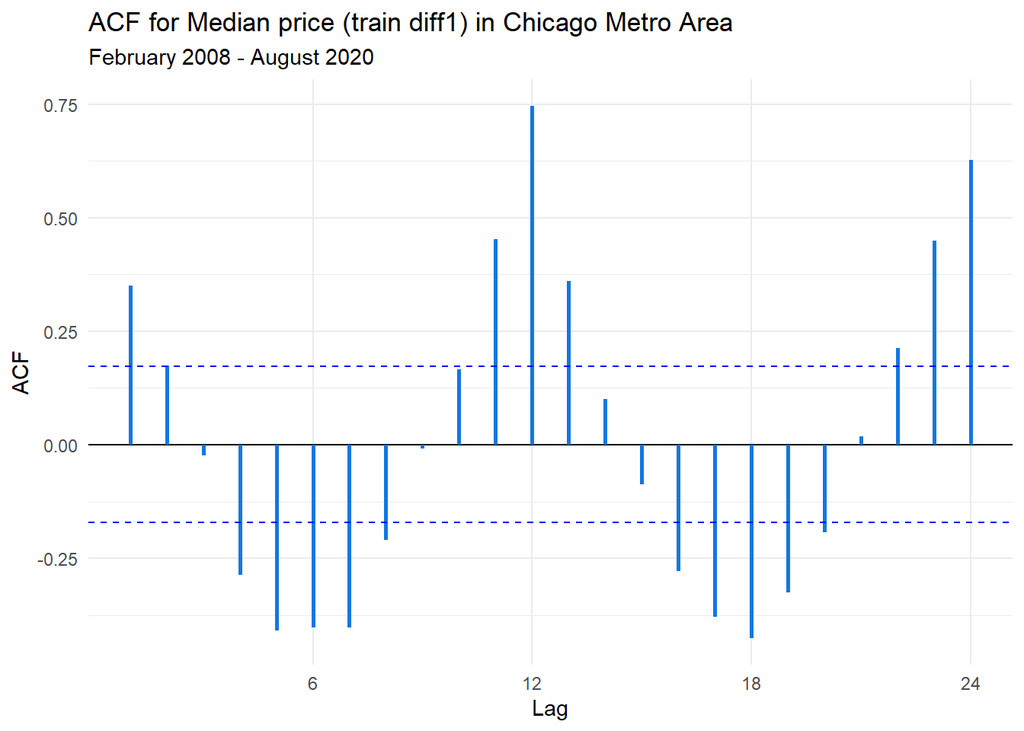

```r
# Check autocorrelation
ggAcf(Median_price_ts_train_diff1, color = "#1277e1", size = 1) +
         labs(title = "ACF for Median price (train diff1) in Chicago Metro Area", subtitle = "February 2008 - August 2020")
```

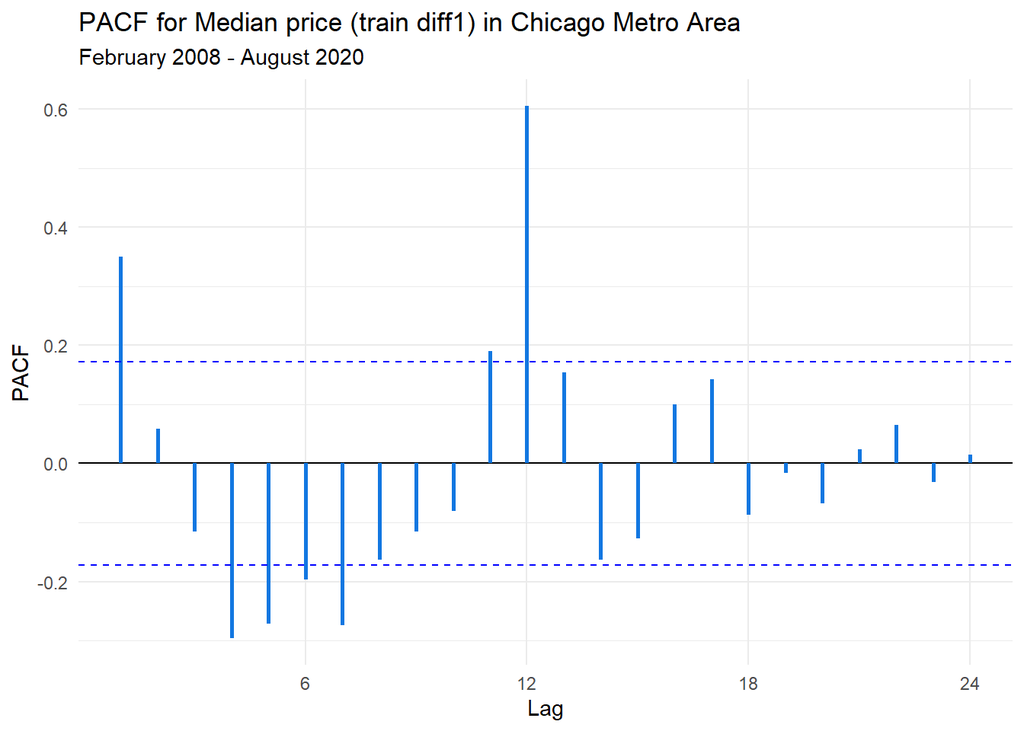

```r
# Check partial autocorrelation
ggPacf(Median_price_ts_train_diff1, color = "#1277e1", size = 1) +
         labs(title = "PACF for Median price (train diff1) in Chicago Metro Area", subtitle = "February 2008 - August 2020")
```

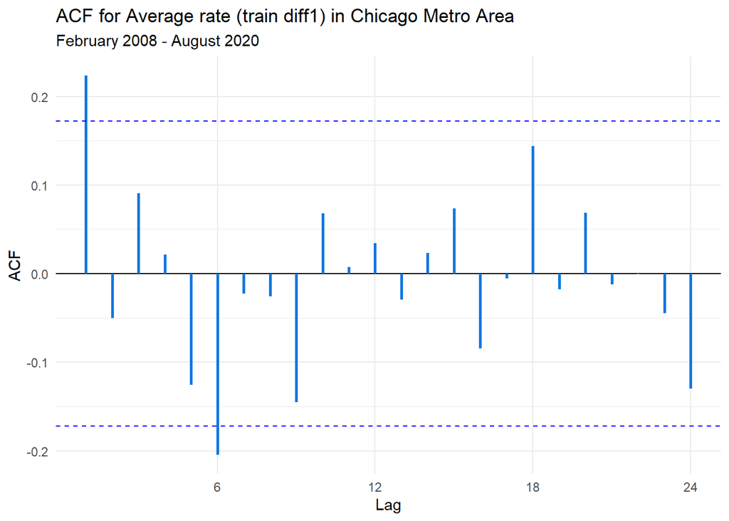

```r
# Check autocorrelation
ggAcf(Average_rate_ts_train_diff1, color = "#1277e1", size = 1) +
         labs(title = "ACF for Average rate (train diff1) in Chicago Metro Area", subtitle = "February 2008 - August 2020")
```

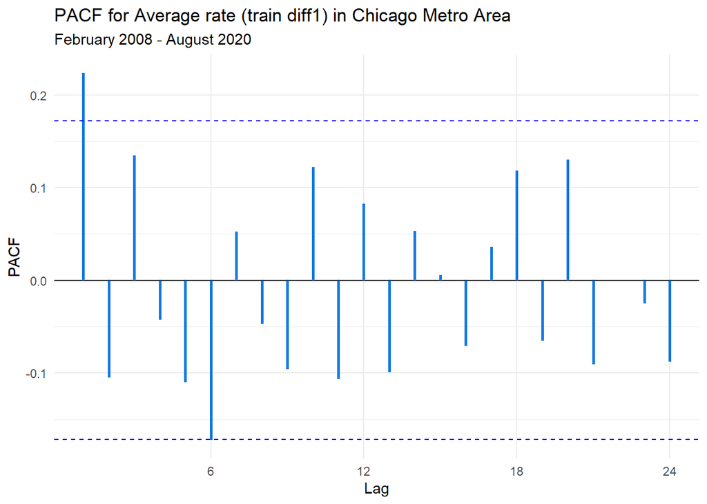

```r
# Check partial autocorrelation
ggPacf(Average_rate_ts_train_diff1, color = "#1277e1", size = 1) +
         labs(title = "PACF for Average rate (train diff1) in Chicago Metro Area", subtitle = "February 2008 - August 2020")
```

As we can see, we have a less strong autocorrelation in both cases, but it still exists, especially with Median price.

#### Tests

```r
kpss.test(Median_price_ts_train_diff1)
```

```
##
##  KPSS Test for Level Stationarity
##
## data:  Median_price_ts_train_diff1
## KPSS Level = 0.094237, Truncation lag parameter = 4, p-value = 0.1
```

```r
kpss.test(Average_rate_ts_train_diff1)
```

```
##
##  KPSS Test for Level Stationarity
##
## data:  Average_rate_ts_train_diff1
## KPSS Level = 0.24027, Truncation lag parameter = 4, p-value = 0.1
```

```r
adf.test(Median_price_ts_train_diff1)
```

```
##
##  Augmented Dickey-Fuller Test
##
## data:  Median_price_ts_train_diff1
## Dickey-Fuller = -8.0937, Lag order = 5, p-value = 0.01
## alternative hypothesis: stationary
```

```r
adf.test(Average_rate_ts_train_diff1)
```

```
##
##  Augmented Dickey-Fuller Test
##
## data:  Average_rate_ts_train_diff1
## Dickey-Fuller = -6.4033, Lag order = 5, p-value = 0.01
## alternative hypothesis: stationary
```

As we can see, both tests for both variables tell us that the process is stationary.

#### VAR select

```r
# Use VAR select
model1_diff1 <- VARselect(cbind(Median_price_ts_train_diff1, Average_rate_ts_train_diff1))

# Print the model
model1_diff1
```

```
## $selection
## AIC(n)  HQ(n)  SC(n) FPE(n)
##      8      1      1      8
##
## $criteria
##                    1             2             3             4             5
## AIC(n)      14.28729      14.33760      14.38670      14.27573      14.23964
## HQ(n)       14.34389      14.43194      14.51876      14.44553      14.44717
## SC(n)       14.42666      14.56990      14.71190      14.69385      14.75068
## FPE(n) 1602872.68045 1685716.45986 1770834.57854 1585310.87920 1529835.03546
##                    6             7             8             9            10
## AIC(n)      14.18468      14.10404      14.03691      14.05536      14.04530
## HQ(n)       14.42995      14.38705      14.35764      14.41383      14.44150
## SC(n)       14.78864      14.80091      14.82669      14.93807      15.02092
## FPE(n) 1449009.63827 1337978.90982 1252613.45009 1277910.57408 1267523.58198
```

`VARselect` offers us to try model with p = 8.

#### Model

```r
# Var 8
varmodel8 <- VAR(cbind(Median_price_ts_train_diff1, Average_rate_ts_train_diff1), p = 8, type = "both", season = 12)

# Pormonteau test
serial.test(varmodel8, lags.pt = 20, type = "PT.asymptotic")
```

```
##
##  Portmanteau Test (asymptotic)
##
## data:  Residuals of VAR object varmodel8
## Chi-squared = 62.194, df = 48, p-value = 0.08182
```

```r
# Print
summary(varmodel8)
```

```
##
## VAR Estimation Results:
## =========================
## Endogenous variables: Median_price_ts_train_diff1, Average_rate_ts_train_diff1
## Deterministic variables: both
## Sample size: 122
## Log Likelihood: -1111.689
## Roots of the characteristic polynomial:
## 0.9225 0.9225 0.8438 0.8438 0.8159 0.8159 0.8128 0.8128 0.8047 0.8047 0.7879 0.7879 0.767 0.767 0.7369 0.7369
## Call:
## VAR(y = cbind(Median_price_ts_train_diff1, Average_rate_ts_train_diff1),
##     p = 8, type = "both", season = 12L)
##
##
## Estimation results for equation Median_price_ts_train_diff1:
## ============================================================
## Median_price_ts_train_diff1 = Median_price_ts_train_diff1.l1 + Average_rate_ts_train_diff1.l1 + Median_price_ts_train_diff1.l2 + Average_rate_ts_train_diff1.l2 + Median_price_ts_train_diff1.l3 + Average_rate_ts_train_diff1.l3 + Median_price_ts_train_diff1.l4 + Average_rate_ts_train_diff1.l4 + Med…
##
##                                    Estimate   Std. Error t value      Pr(>|t|)
## Median_price_ts_train_diff1.l1    -0.094893     0.102721  -0.924      0.357982
## Average_rate_ts_train_diff1.l1 -2050.909009  3173.751968  -0.646      0.519735
## Median_price_ts_train_diff1.l2     0.152313     0.103056   1.478      0.142795
## Average_rate_ts_train_diff1.l2  2468.956733  3132.128758   0.788      0.432545
## Median_price_ts_train_diff1.l3    -0.039644     0.106797  -0.371      0.711324
## Average_rate_ts_train_diff1.l3 -4332.978143  3028.277217  -1.431      0.155828
## Median_price_ts_train_diff1.l4    -0.226741     0.103863  -2.183      0.031547
## Average_rate_ts_train_diff1.l4  5383.821663  3038.065159   1.772      0.079649
## Median_price_ts_train_diff1.l5    -0.197276     0.102409  -1.926      0.057114
## Average_rate_ts_train_diff1.l5   842.486275  3019.910908   0.279      0.780882
## Median_price_ts_train_diff1.l6     0.005893     0.106892   0.055      0.956150
## Average_rate_ts_train_diff1.l6  -578.452712  2989.378362  -0.194      0.846987
## Median_price_ts_train_diff1.l7    -0.171665     0.104305  -1.646      0.103179
## Average_rate_ts_train_diff1.l7  2329.520500  3105.891889   0.750      0.455128
## Median_price_ts_train_diff1.l8    -0.090824     0.102049  -0.890      0.375761
## Average_rate_ts_train_diff1.l8 -4773.256138  2999.871077  -1.591      0.114969
## const                          -3217.964043  1243.703644  -2.587      0.011220
## trend                             43.515735    16.019049   2.716      0.007868
## sd1                            18691.697093  2821.332626   6.625 0.00000000222
## sd2                            15755.944459  3920.935911   4.018      0.000119
## sd3                             7793.355925  4178.513309   1.865      0.065320
```

[output cut: 91 more lines]

```
## Covariance matrix of residuals:
##                             Median_price_ts_train_diff1
## Median_price_ts_train_diff1                  21801207.9
## Average_rate_ts_train_diff1                       103.7
##                             Average_rate_ts_train_diff1
## Median_price_ts_train_diff1                   103.73733
## Average_rate_ts_train_diff1                     0.02273
##
## Correlation matrix of residuals:
##                             Median_price_ts_train_diff1
## Median_price_ts_train_diff1                      1.0000
## Average_rate_ts_train_diff1                      0.1474
##                             Average_rate_ts_train_diff1
## Median_price_ts_train_diff1                      0.1474
## Average_rate_ts_train_diff1                      1.0000
```

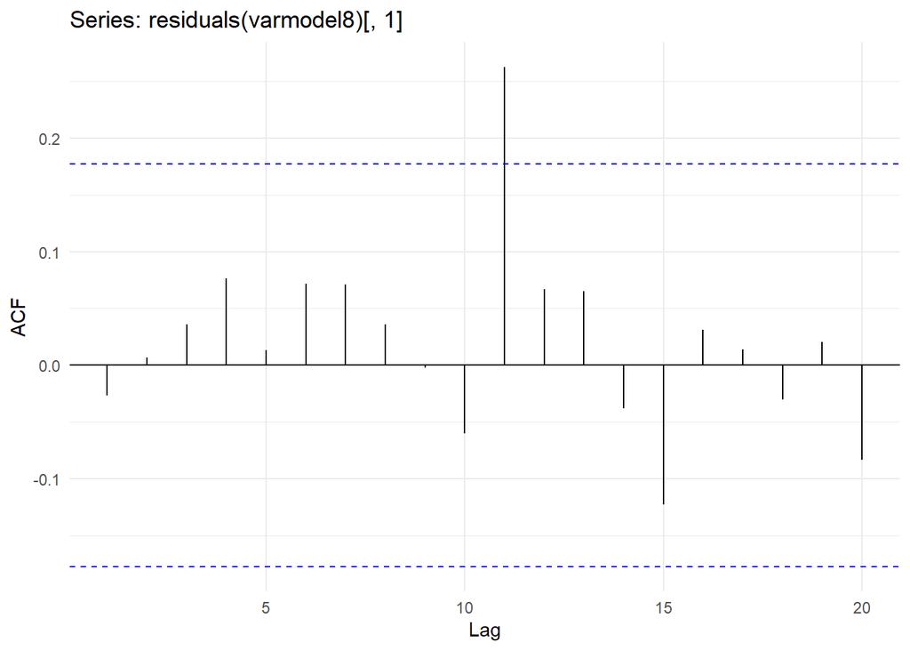

```r
# Check residuals for the model
ggAcf(residuals(varmodel8)[, 1])
```

#### Forecast

```r
# Create a forecast
varmodel8_forecast <- ts(predict(varmodel8, n.ahead = 12, ci = .95)$fcst$Median_price_ts_train[, 1], start = test_start, frequency = 12)
```

#### Evaluate the model

```r
# Analyze accuracy
accuracy(varmodel8_forecast, Median_price_ts_test_diff1)
```

```
##                 ME    RMSE      MAE       MPE     MAPE       ACF1 Theil's U
## Test set -1106.187 4412.83 3502.727 -3.134251 139.6127 -0.3275504  1.139328
```

```r
accuracy(varmodel8_forecast, Average_rate_ts_test_diff1)
```

```
##                 ME     RMSE      MAE      MPE     MAPE      ACF1 Theil's U
## Test set -1939.597 8061.648 6329.194 -1788137 10487641 0.4442023  59444.59
```

#### Cross-validation

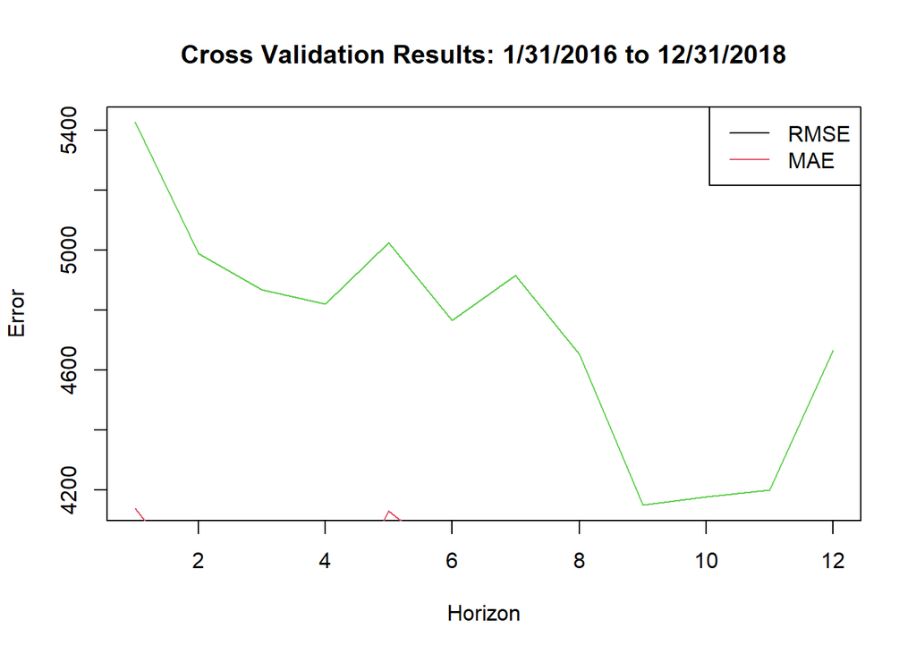

```r
# Define parameters
k <- 72 # Minimum observations (6 years)
p <- 12 # Period
st <- 2014 + 11/12
error <- matrix(NA, 36, 12)
dates <- c()
for(i in (1:36))

# Create a function
{
  train <- window(Median_price_ts_diff1, start = st + (i - k + 1)/p, end = st + i/p)
  test <- window(Median_price_ts_diff1, start = st + (i + 1)/p, end = st + (i + 12)/p)
  rate_train <- window(Average_rate_ts_diff1, start = st + (i - k + 1)/p, end = st + i/p)
  rate_test <- window(Average_rate_ts_diff1, start = st + (i + 1)/p, end = st+(i + 12)/p)
  dates[i] <- st + (i + 12)/p
  var_model <-  VAR(cbind(train, rate_train), p = 8, type = "both", season = 12)

  f <- ts(predict(var_model, n.ahead = 12, ci = .95)$fcst$train[, 1], start = st + (i + 1)/p, frequency = 12)
  error[i, 1:length(test)] <- f - test
}

# Define and plot metrics
MAE <- colMeans(abs(error), na.rm = TRUE)
RMSE <- sqrt(colMeans(error**2, na.rm = TRUE))
plot(1:12, RMSE, type = "l", col = 3, xlab = "Horizon", ylab = "Error", main = 'Cross Validation Results: 1/31/2016 to 12/31/2018')
lines(1:12, MAE, type = "l", col = 2)
legend("topright", legend = c("RMSE", "MAE"), col = 1:4, lty = 1)
```

```r
# Print metrics
print(MAE)
```

```
##  [1] 4137.856 3869.614 3835.481 3722.199 4128.558 3962.064 4020.871 3827.715
##  [9] 3427.591 3469.225 3506.593 3861.817
```

```r
print(RMSE)
```

```
##  [1] 5426.477 4988.847 4868.120 4820.040 5024.501 4765.767 4915.846 4652.840
##  [9] 4149.079 4175.717 4198.702 4665.633
```

```r
print(sum(MAE)/12)
```

```
## [1] 3814.132
```

```r
print(sum(RMSE)/12)
```

```
## [1] 4720.964
```

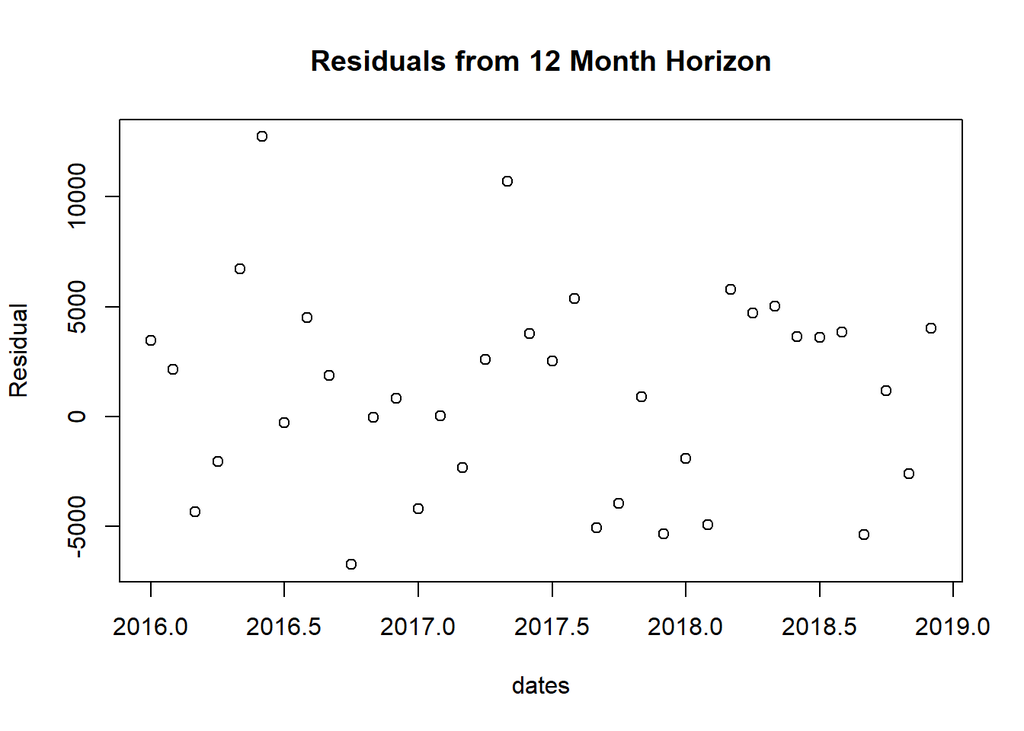

```r
# Plot residuals
plot(dates, error[, 12], ylab = 'Residual', main = 'Residuals from 12 Month Horizon')
```

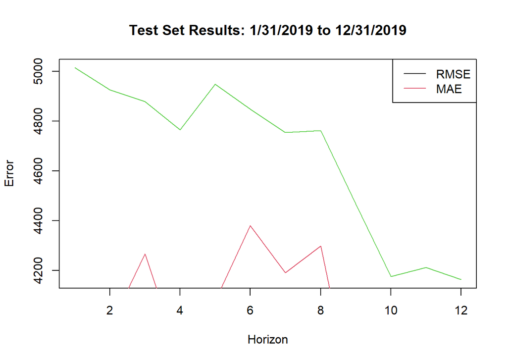

```r
error <- matrix(NA, 12, 12)
dates <- c()
for(i in (37:48))

{
  train <- window(Median_price_ts_diff1, start = st + (i - k + 1)/p, end = st + i/p)
  test <- window(Median_price_ts_diff1, start = st + (i + 1)/p, end = st + (i + 12)/p)
  rate_train <- window(Average_rate_ts_diff1, start = st + (i - k + 1)/p, end = st + i/p)
  rate_test <- window(Average_rate_ts_diff1, start = st + (i + 1)/p, end = st + (i + 12)/p)
  dates[i - 36] <- st + (i + 12)/p
  var_model <-  VAR(cbind(train, rate_train), p = 8, type = "both", season = 12)

  f <- ts(predict(var_model, n.ahead = 12, ci = .95)$fcst$train[, 1], start = st + (i + 1)/p, frequency = 12)
  error[i - 36, 1:length(test)] <- f - test
}

# Define metrics and plot them
MAE <- colMeans(abs(error), na.rm = TRUE)
RMSE <- sqrt(colMeans(error**2, na.rm = TRUE))
plot(1:12, RMSE, type = "l",col = 3, xlab = "Horizon", ylab = "Error", main = 'Test Set Results: 1/31/2019 to 12/31/2019')
lines(1:12, MAE, type = "l", col = 2)
legend("topright", legend = c("RMSE", "MAE"), col = 1:4, lty = 1)
```

```r
# Print metrics
print(MAE)
```

```
##  [1] 4029.479 3975.509 4267.597 3849.119 4077.562 4381.696 4191.133 4298.965
##  [9] 3622.607 3557.988 3512.950 3344.559
```

```r
print(RMSE)
```

```
##  [1] 5015.267 4926.110 4879.672 4765.306 4948.793 4849.048 4755.786 4763.106
##  [9] 4467.232 4175.838 4213.198 4164.031
```

```r
print(sum(MAE)/12)
```

```
## [1] 3925.764
```

```r
print(sum(RMSE)/12)
```

```
## [1] 4660.282
```

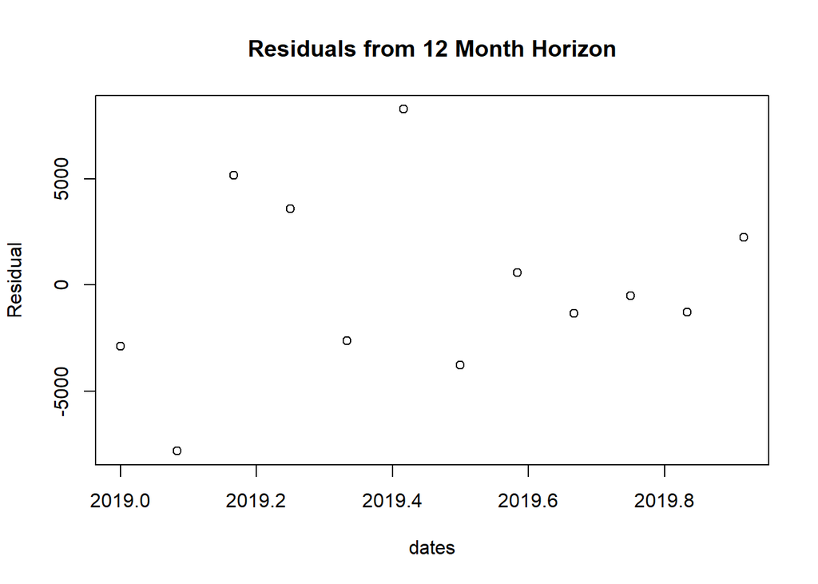

```r
# Plot residuals
plot(dates, error[, 12], ylab = 'Residual', main = 'Residuals from 12 Month Horizon')
```

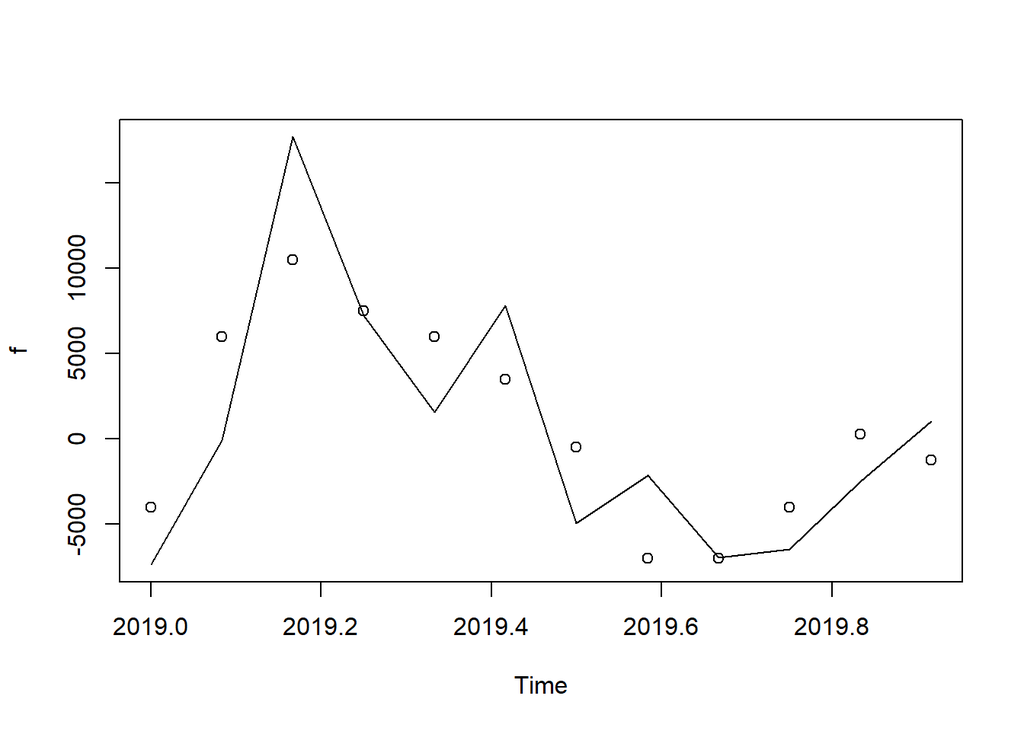

```r
# Compare results
plot(f)
points(test)
```

### VAR with Diff2

#### 2st order differencing

Again, we need to difference data (2st order)

```r
# Create new variables
Median_price_ts_diff2 <- diff(Median_price_ts, differences = 2)
Average_rate_ts_diff2 <- diff(Average_rate_ts, differences = 2)

# Check class
class(Median_price_ts_diff2)
```

```
## [1] "ts"
```

```r
class(Average_rate_ts_diff2)
```

```
## [1] "ts"
```

```r
# Print
Median_price_ts_diff2
```

```
##         Jan    Feb    Mar    Apr    May    Jun    Jul    Aug    Sep    Oct
## 2008                        7000  -2000   4000  -1500  -7000  -6500      0
## 2009 -12000   1000  20000 -10000   3000   4000 -11700   4400  -8700      0
## 2010  -4000  -5000  22000 -12000   5500   6000 -22500  16600 -23200  16300
## 2011 -11500   8750  -4500  20000 -14500  12000  -6000 -10000 -15000  15000
## 2012  -4000   4000  18000  -5000  -4500  12000 -20500  -6000      0  -6000
## 2013 -11000   8000  19000      0  -2000   8750 -22500  -3750  -6500  -1100
## 2014  -3000  -3000  24000  -6500   5500   2500 -22500   7500 -19000   3000
## 2015  -8000   5000  23000  -7000  -5000    500 -12100  -3300  -1100   1000
## 2016 -10000   4995  24260  -3505 -12000   -500  -6250  -5000  -6000  13000
## 2017  -3000   1000  20000  -6000 -12500  10000 -15000  -5300   2600   3700
## 2018  -9750   7375  10000  -3500  -8000   8900 -16800  -3100   6000  -3000
## 2019  -1000  10000   4500  -3000  -1500  -2500  -4000  -6500      0   3000
## 2020  -5750   9000  21000 -11000 -21000  12000   5000      0
##         Nov    Dec
## 2008      0  11000
## 2009   7000   2000
## 2010  -9400  10450
## 2011  -2000   4000
## 2012  19000  -5000
## 2013   8700   1400
## 2014  11000   2500
## 2015   2000   6000
## 2016  -2500   3000
## 2017   1000   7875
## 2018   8000  -4000
## 2019   4250  -1500
## 2020
```

```r
Average_rate_ts_diff2
```

```
##        Jan   Feb   Mar   Apr   May   Jun   Jul   Aug   Sep   Oct   Nov   Dec
## 2008                   -0.10  0.17  0.16 -0.17 -0.06 -0.49  0.60 -0.27 -0.69
## 2009  0.56  0.32 -0.21 -0.06  0.24  0.51 -0.76  0.17 -0.10  0.02  0.04  0.12
## 2010  0.05 -0.14  0.02  0.15 -0.34  0.06 -0.03  0.05  0.05 -0.05  0.21  0.33
## 2011 -0.36  0.14 -0.30  0.11 -0.20  0.07  0.16 -0.30  0.11  0.12 -0.04  0.05
## 2012 -0.01  0.01  0.09 -0.10 -0.07 -0.02  0.01  0.17 -0.15 -0.02  0.09  0.02
## 2013  0.08  0.05 -0.09 -0.14  0.20  0.44 -0.23 -0.21 -0.06 -0.33  0.37  0.13
## 2014 -0.23 -0.10  0.17 -0.04 -0.15  0.12  0.00  0.02  0.05 -0.16  0.08 -0.10
## 2015 -0.05  0.23  0.02 -0.16  0.27 -0.03 -0.07 -0.21  0.12 -0.07  0.23 -0.12
## 2016 -0.11 -0.12  0.24 -0.12  0.09 -0.03 -0.10  0.13  0.02 -0.01  0.29  0.13
## 2017 -0.48  0.07  0.01 -0.19  0.13 -0.08  0.18 -0.16  0.01  0.18 -0.08  0.01
## 2018  0.05  0.22 -0.19 -0.08  0.09 -0.14 -0.02  0.06  0.06  0.12 -0.16 -0.27
## 2019  0.05  0.09 -0.02 -0.01  0.05 -0.20  0.24 -0.12  0.13  0.11 -0.08  0.01
## 2020 -0.12 -0.05  0.13 -0.12  0.06  0.01 -0.07  0.06
```

```r
# Define again train and test
Median_price_ts_train_diff2 <- window(Median_price_ts_diff2, end = train_end)
Median_price_ts_test_diff2 <- window(Median_price_ts_diff2, start = test_start, end = test_end)
```

```r
# Define again train and test
Average_rate_ts_train_diff2 <- window(Average_rate_ts_diff2, end = train_end)
Average_rate_ts_test_diff2 <- window(Average_rate_ts_diff2, start = test_start, end = test_end)
```

```r
# Check correlation
cor(Median_price_ts_train_diff2, Average_rate_ts_train_diff2)
```

```
## [1] 0.1329789
```

We can see that our corrlation dropped slightly this time.

#### Stationarity

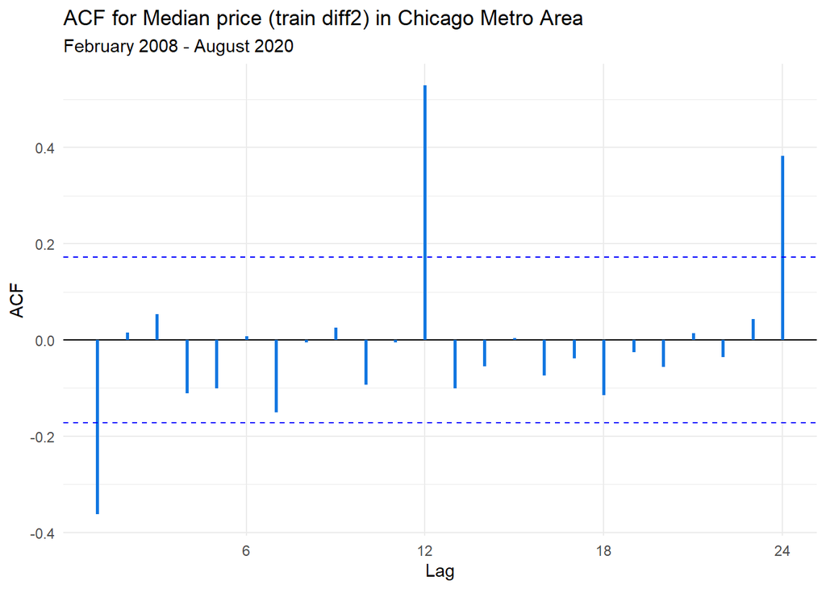

```r
# Check autocorrelation for Median price
ggAcf(Median_price_ts_train_diff2, color = "#1277e1", size = 1) +
         labs(title = "ACF for Median price (train diff2) in Chicago Metro Area", subtitle = "February 2008 - August 2020")
```

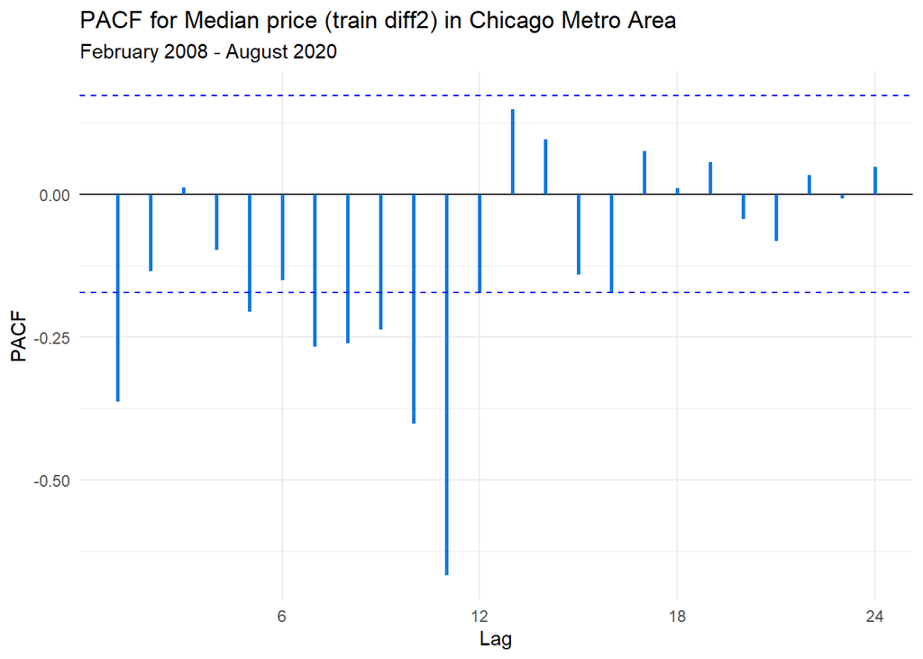

```r
# Check partial autocorrelation
ggPacf(Median_price_ts_train_diff2, color = "#1277e1", size = 1) +
         labs(title = "PACF for Median price (train diff2) in Chicago Metro Area", subtitle = "February 2008 - August 2020")
```

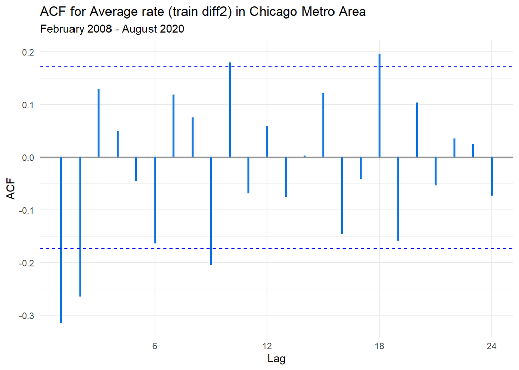

```r
# Check autocorrelation
ggAcf(Average_rate_ts_train_diff2, color = "#1277e1", size = 1) +
         labs(title = "ACF for Average rate (train diff2) in Chicago Metro Area", subtitle = "February 2008 - August 2020")
```

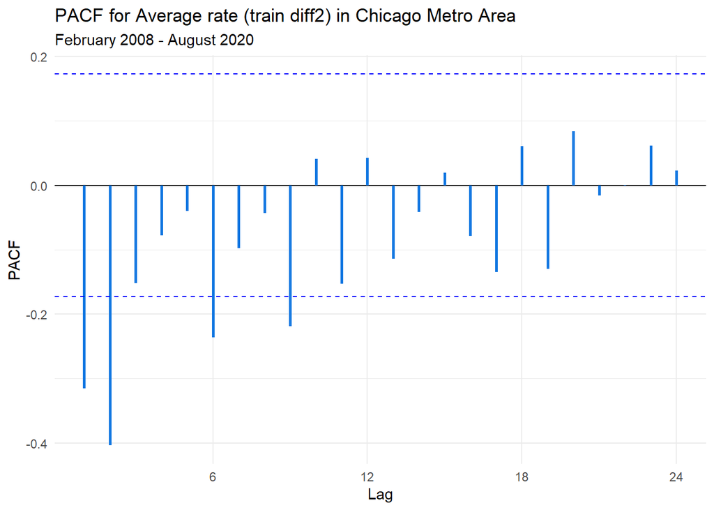

```r
# Check partial autocorrelation
ggPacf(Average_rate_ts_train_diff2, color = "#1277e1", size = 1) +
         labs(title = "PACF for Average rate (train diff2) in Chicago Metro Area", subtitle = "February 2008 - August 2020")
```

#### Tests

```r
kpss.test(Median_price_ts_train_diff2)
```

```
##
##  KPSS Test for Level Stationarity
##
## data:  Median_price_ts_train_diff2
## KPSS Level = 0.015469, Truncation lag parameter = 4, p-value = 0.1
```

```r
kpss.test(Average_rate_ts_train_diff2)
```

```
##
##  KPSS Test for Level Stationarity
##
## data:  Average_rate_ts_train_diff2
## KPSS Level = 0.02708, Truncation lag parameter = 4, p-value = 0.1
```

```r
adf.test(Median_price_ts_train_diff2)
```

```
##
##  Augmented Dickey-Fuller Test
##
## data:  Median_price_ts_train_diff2
## Dickey-Fuller = -6.8136, Lag order = 5, p-value = 0.01
## alternative hypothesis: stationary
```

```r
adf.test(Average_rate_ts_train_diff2)
```

```
##
##  Augmented Dickey-Fuller Test
##
## data:  Average_rate_ts_train_diff2
## Dickey-Fuller = -7.3257, Lag order = 5, p-value = 0.01
## alternative hypothesis: stationary
```

#### VAR select

```r
# Use VAR select
model1_diff2 <- VARselect(cbind(Median_price_ts_train_diff2, Average_rate_ts_train_diff2))

# Print the model
model1_diff2
```

```
## $selection
## AIC(n)  HQ(n)  SC(n) FPE(n)
##     10     10      2     10
##
## $criteria
##                    1             2             3             4             5
## AIC(n)      14.95668      14.86010      14.84228      14.87840      14.85674
## HQ(n)       15.01358      14.95493      14.97505      15.04910      15.06537
## SC(n)       15.09681      15.09364      15.16923      15.29877      15.37053
## FPE(n) 3130509.56887 2842507.10350 2792787.53925 2896390.08745 2835698.37878
##                    6             7             8             9            10
## AIC(n)      14.81285      14.74741      14.63586      14.47334      14.33573
## HQ(n)       15.05941      15.03191      14.95829      14.83371      14.73403
## SC(n)       15.42005      15.44803      15.42989      15.36080      15.31660
## FPE(n) 2715804.72059 2546173.59508 2280244.74129 1941276.62507 1695011.91349
```

`VARselect` offers us to try model with p = 10.

#### Model

```r
# Var 10
varmodel10_diff2 <- VAR(cbind(Median_price_ts_train_diff2, Average_rate_ts_train_diff2), p = 10, type = "both", season = 12)

# Pormonteau test
serial.test(varmodel10_diff2, lags.pt = 20, type = "PT.asymptotic")
```

```
##
##  Portmanteau Test (asymptotic)
##
## data:  Residuals of VAR object varmodel10_diff2
## Chi-squared = 56.241, df = 40, p-value = 0.0457
```

```r
summary(varmodel10_diff2)
```

```
##
## VAR Estimation Results:
## =========================
## Endogenous variables: Median_price_ts_train_diff2, Average_rate_ts_train_diff2
## Deterministic variables: both
## Sample size: 119
## Log Likelihood: -1077.358
## Roots of the characteristic polynomial:
## 0.955 0.955 0.925 0.925 0.912 0.912 0.9021 0.9021 0.9014 0.9014 0.9005 0.9005 0.8885 0.8885 0.8835 0.8835 0.8827 0.8808 0.8808 0.178
## Call:
## VAR(y = cbind(Median_price_ts_train_diff2, Average_rate_ts_train_diff2),
##     p = 10, type = "both", season = 12L)
##
##
## Estimation results for equation Median_price_ts_train_diff2:
## ============================================================
## Median_price_ts_train_diff2 = Median_price_ts_train_diff2.l1 + Average_rate_ts_train_diff2.l1 + Median_price_ts_train_diff2.l2 + Average_rate_ts_train_diff2.l2 + Median_price_ts_train_diff2.l3 + Average_rate_ts_train_diff2.l3 + Median_price_ts_train_diff2.l4 + Average_rate_ts_train_diff2.l4 + Med…
##
##                                     Estimate   Std. Error t value
## Median_price_ts_train_diff2.l1      -1.02621      0.09876 -10.391
## Average_rate_ts_train_diff2.l1    1028.26382   3600.63409   0.286
## Median_price_ts_train_diff2.l2      -0.75112      0.13352  -5.626
## Average_rate_ts_train_diff2.l2     931.94097   3862.82901   0.241
## Median_price_ts_train_diff2.l3      -0.65029      0.14316  -4.542
## Average_rate_ts_train_diff2.l3   -4441.70366   4043.43073  -1.098
## Median_price_ts_train_diff2.l4      -0.73081      0.14739  -4.958
## Average_rate_ts_train_diff2.l4    1350.14215   4123.34379   0.327
## Median_price_ts_train_diff2.l5      -0.82375      0.15003  -5.490
## Average_rate_ts_train_diff2.l5    1942.79694   3739.18358   0.520
## Median_price_ts_train_diff2.l6      -0.63572      0.14677  -4.332
## Average_rate_ts_train_diff2.l6    4230.16983   3714.73181   1.139
## Median_price_ts_train_diff2.l7      -0.65252      0.13950  -4.677
## Average_rate_ts_train_diff2.l7    7034.40757   3918.24073   1.795
## Median_price_ts_train_diff2.l8      -0.67914      0.14041  -4.837
## Average_rate_ts_train_diff2.l8     762.75317   3855.84459   0.198
## Median_price_ts_train_diff2.l9      -0.59548      0.13555  -4.393
## Average_rate_ts_train_diff2.l9   -1170.40970   3417.57125  -0.342
## Median_price_ts_train_diff2.l10     -0.41511      0.09887  -4.199
## Average_rate_ts_train_diff2.l10  -1714.24048   3050.32284  -0.562
## const                              873.14078    994.32116   0.878
```

[output cut: 137 more lines]

```
## Covariance matrix of residuals:
##                             Median_price_ts_train_diff2
## Median_price_ts_train_diff2                  22069421.2
## Average_rate_ts_train_diff2                       128.6
##                             Average_rate_ts_train_diff2
## Median_price_ts_train_diff2                   128.59743
## Average_rate_ts_train_diff2                     0.02248
##
## Correlation matrix of residuals:
##                             Median_price_ts_train_diff2
## Median_price_ts_train_diff2                      1.0000
## Average_rate_ts_train_diff2                      0.1826
##                             Average_rate_ts_train_diff2
## Median_price_ts_train_diff2                      0.1826
## Average_rate_ts_train_diff2                      1.0000
```

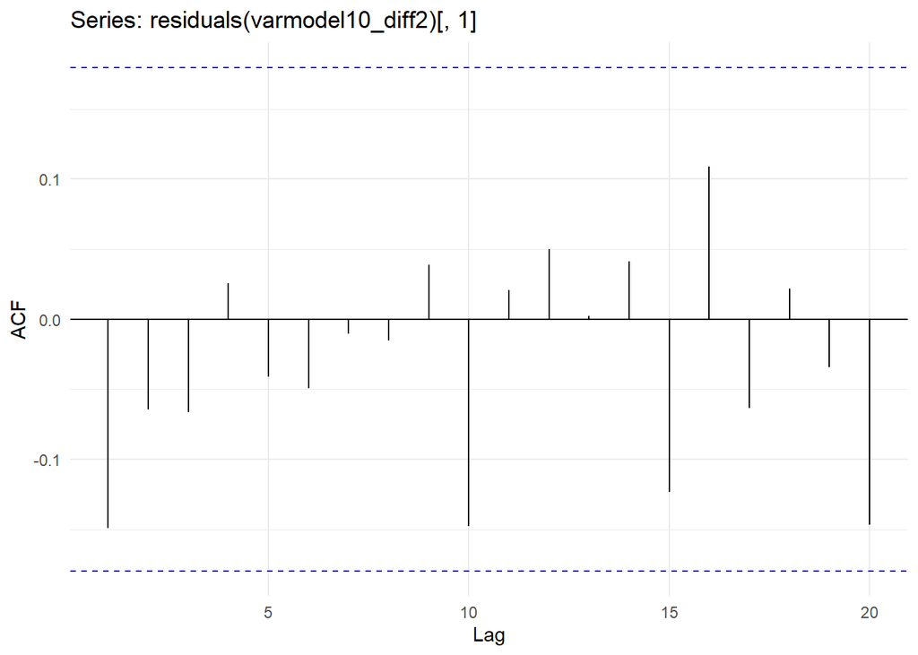

```r
# Check residuals for the model
ggAcf(residuals(varmodel10_diff2)[, 1])
```

#### Forecast

```r
# Create a forecast
varmodel10_diff2_forecast <- ts(predict(varmodel10_diff2, n.ahead = 12, ci = .95)$fcst$Median_price_ts_train[, 1], start = test_start, frequency = 12)
```

#### Evaluate the model

```r
# Analyze accuracy
accuracy(varmodel10_diff2_forecast, Median_price_ts_test_diff2)
```

```
##                 ME   RMSE      MAE MPE MAPE       ACF1 Theil's U
## Test set -121.4803 7642.6 6514.604 Inf  Inf -0.6861545         0
```

```r
accuracy(varmodel10_diff2_forecast, Average_rate_ts_test_diff2)
```

```
##                 ME    RMSE     MAE      MPE     MAPE       ACF1 Theil's U
## Test set -267.2928 8243.07 6154.13 -1184520 22971202 -0.3539065  66075.09
```

#### Cross-validation

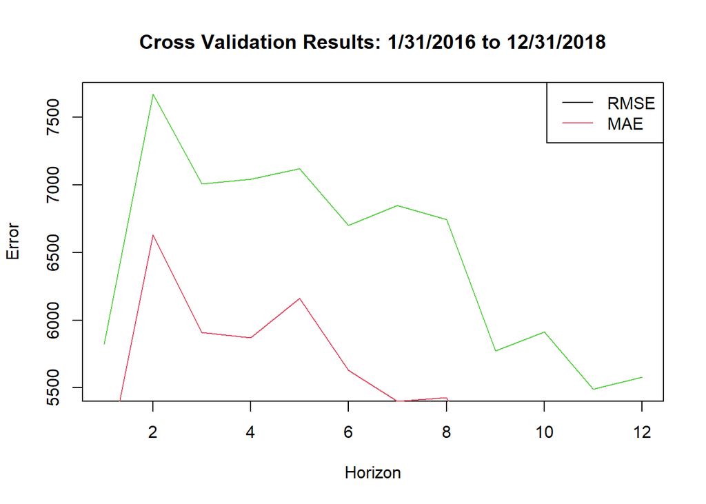

```r
# Define parameters
k <- 72 # Minimum observations (6 years)
p <- 12 # Period
st <- 2014 + 11/12
error <- matrix(NA, 36, 12)
dates <- c()
for(i in (1:36))

# Create a function
{
  train <- window(Median_price_ts_diff2, start = st + (i - k + 1)/p, end = st + i/p)
  test <- window(Median_price_ts_diff2, start = st + (i + 1)/p, end = st + (i + 12)/p)
  rate_train <- window(Average_rate_ts_diff2, start = st + (i - k + 1)/p, end = st + i/p)
  rate_test <- window(Average_rate_ts_diff2, start = st + (i + 1)/p, end = st+(i + 12)/p)
  dates[i] <- st + (i + 12)/p
  var_model <-  VAR(cbind(train, rate_train), p = 10, type = "both", season = 12)

  f <- ts(predict(var_model, n.ahead = 12, ci = .95)$fcst$train[, 1], start = st + (i + 1)/p, frequency = 12)
  error[i, 1:length(test)] <- f - test
}

# Define and plot metrics
MAE <- colMeans(abs(error), na.rm = TRUE)
RMSE <- sqrt(colMeans(error**2, na.rm = TRUE))
plot(1:12, RMSE, type = "l", col = 3, xlab = "Horizon", ylab = "Error", main = 'Cross Validation Results: 1/31/2016 to 12/31/2018')
lines(1:12, MAE, type = "l", col = 2)
legend("topright", legend = c("RMSE", "MAE"), col = 1:4, lty = 1)
```

```r
# Print metrics
print(MAE)
```

```
##  [1] 4829.137 6631.993 5909.969 5869.331 6162.082 5631.466 5402.209 5429.312
##  [9] 4600.350 4584.454 4271.574 4561.094
```

```r
print(RMSE)
```

```
##  [1] 5823.217 7670.728 7009.420 7043.693 7122.444 6701.673 6848.087 6742.949
##  [9] 5773.926 5914.302 5489.010 5578.910
```

```r
print(sum(MAE)/12)
```

```
## [1] 5323.581
```

```r
print(sum(RMSE)/12)
```

```
## [1] 6476.53
```

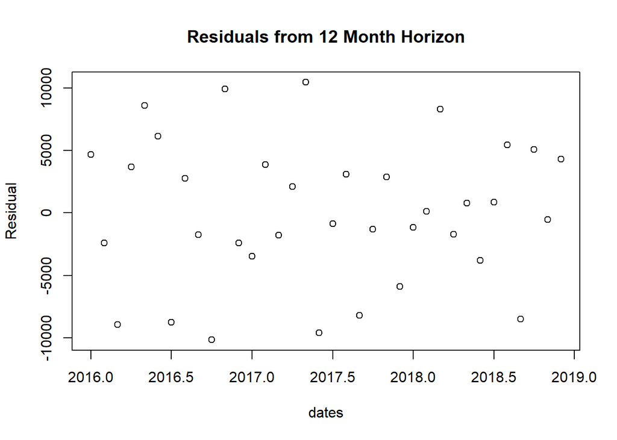

```r
# Plot residuals
plot(dates, error[, 12], ylab = 'Residual', main = 'Residuals from 12 Month Horizon')
```